# 3-ой этап индивидуального проекта

Операционные системы

Верниковская Е. А., НПИбд-01-23

Российский университет дружбы народов, Москва, Россия

3 апреля 2024

# Вводная часть

## Цель работы

Добавить к сайту достижения.

## Задание

1. Добавить информацию о навыках (Skills).
2. Добавить информацию об опыте (Experience).
3. Добавить информацию о достижениях (Accomplishments).
4. Сделать пост по прошедшей неделе.
5. Добавить пост на тему по выбору:
- Легковесные языки разметки.
- Языки разметки. LaTeX.
- Язык разметки Markdown.

# Выполнение 3-ого этапа индивидуального проекта

## Добавление информации о навыках (skills)

Заходим в каталог ~/work/blog. Далее запускаем исполняемый файл hugo, с помощью команды *~/bin/hugo server* и переходим на наш локальный сайт (рис. 1)

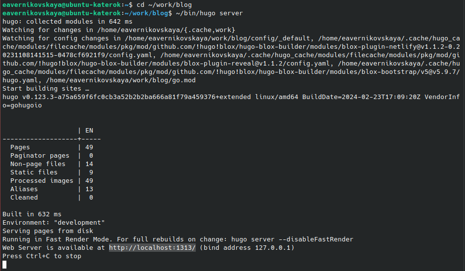

Запуск исполняемого файла

## Добавление информации о навыках (skills)

Потом переходим в каталог ~/work/blog/content/authors/admin и редактируем файл _index.md. Добавляем информацию о навыках (skills) а точнее о наших хобби и технических навыков (рис. 2), (рис. 3)

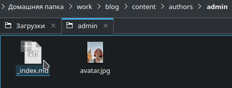

Переход в нужный каталог ~/work/blog/content/authors/admin

## Добавление информации о навыках (skills)

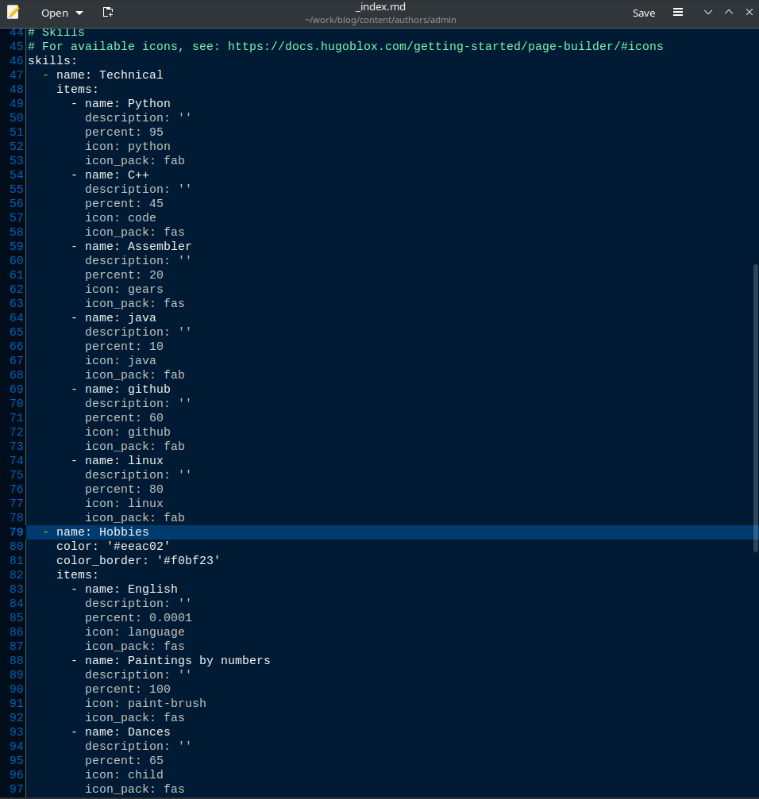

Редактирование файла _index.md

## Добавление информации о навыках (skills)

Иконки для навыков можно найти в интернете в официальной библиотеке иконок fas и fab (рис. 4), (рис. 5), (рис. 6])

[figure not shown]

Сайт официальной библиотеки с иконками

## Добавление информации о навыках (skills)

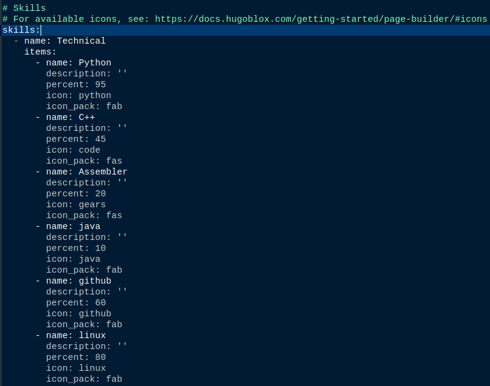

Отредактированные технические навыки

## Добавление информации о навыках (skills)

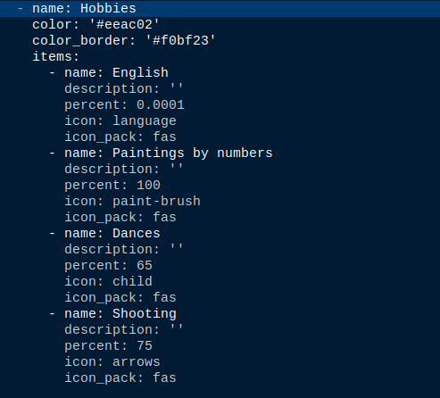

Отредактированные хобби

## Добавление информации об опыте (experience)

Далее переходим в каталог ~/work/blog/content и редактируем файл _index.md уже там (рис. 7)

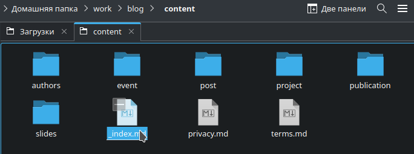

Переход в нужный каталог ~/work/blog/content

## Добавление информации об опыте (experience)

Добавляем информацию об опыте, отредактировав блок с названием experience (рис. 8)

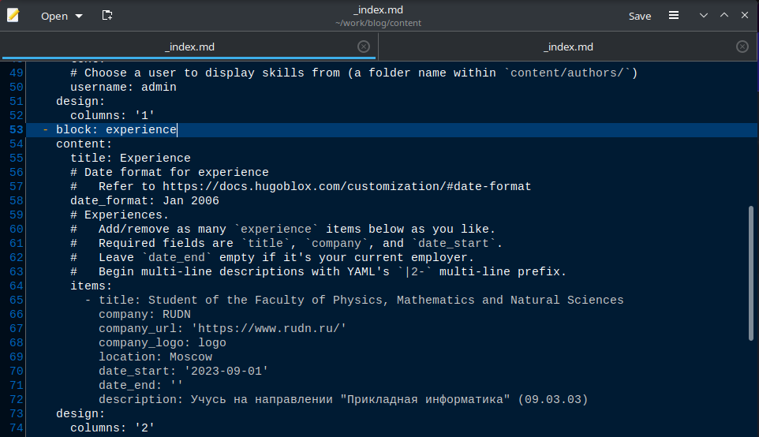

Отредактированный опыт

## Добавление информации о достижениях (accomplishments)

Потом в том же файле добавляем информацию о достижениях, отредактировав блок с названием accomplishments (рис. 9)

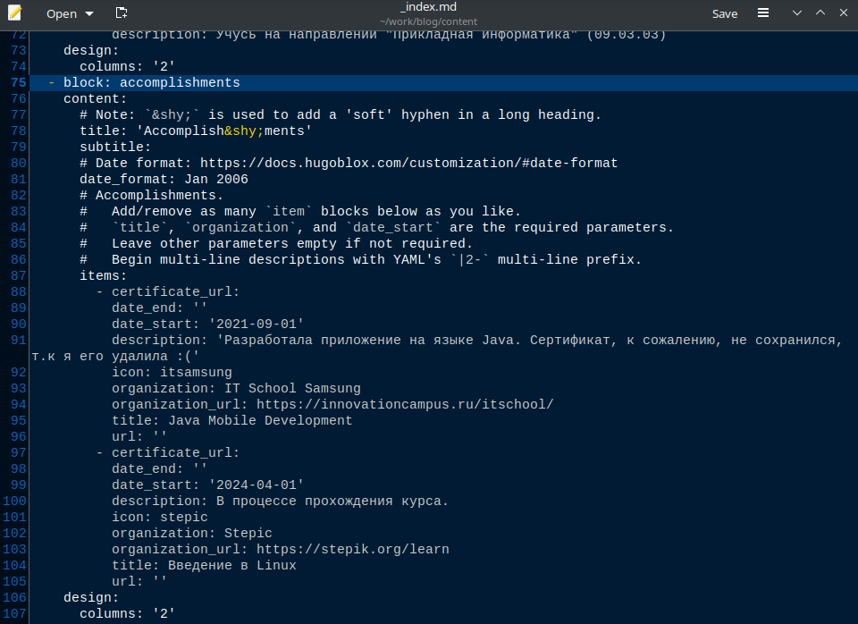

Отредактированные достижения

## Добавление информации о достижениях (accomplishments)

Добаялем нужные логотипы организаций в каталог ~/work/blog/assets/media/icons/brands. Картинки должны быт в формате *svg* (рис. 10)

[figure not shown]

Каталог с логотипами

## Размещение постов на сайте

Переходим в каталог ~/work/blog/content/post и создаём две папки (я назвала их *post_3* и *post_4*), где будут хранится материалы постов (рис. 11), (рис. 12), (рис. 13)

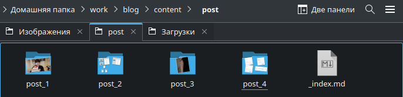

Папки с материалама постов

## Размещение постов на сайте

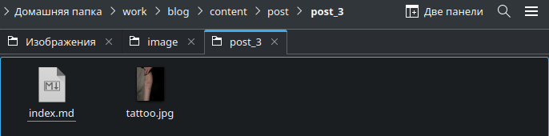

Материалы для поста о прошедшей неделе

## Размещение постов на сайте

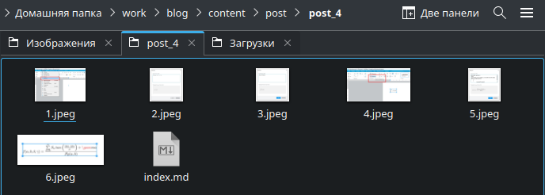

Материалы для поста по выбранной теме

## Размещение постов на сайте

Редактируем в папке post_3 файл index.md. Пишем там пост о нашей прошедшей неделе, по желанию вставляем картинки (рис. 14)

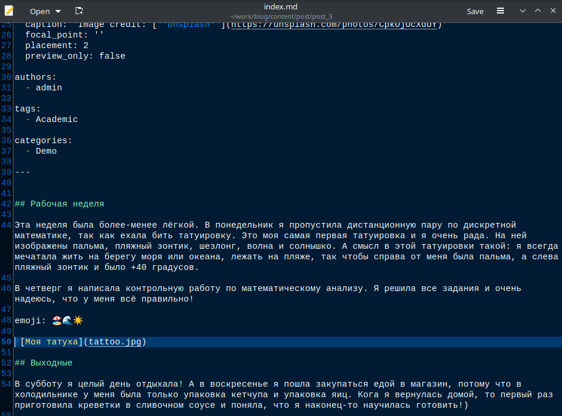

Файл поста по прошедшей неделе

## Размещение постов на сайте

Далее редактируем другой файл index.md в папке post_4. Я выбрала тему “Языки разметки. LaTeX.” (рис. 15)

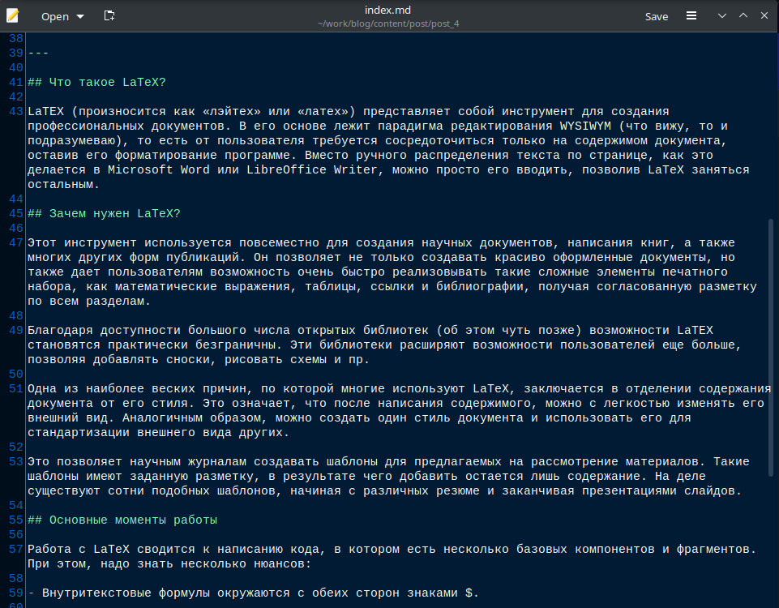

Файл поста по выборанной теме

## Сборка сайта

Собираем наш сайт выполнив в каталоге ~/work/blog команду *~/bin/hugo* (рис. 16)

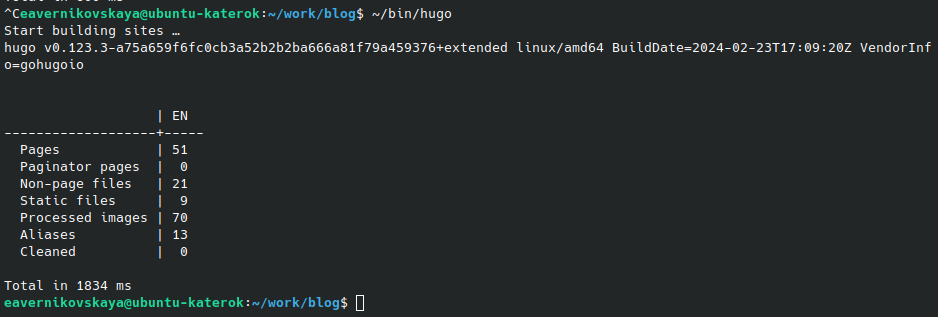

Сборка сайта

## Сборка сайта

Далее сохраняем изменения и отправляем их на git (рис. 17)

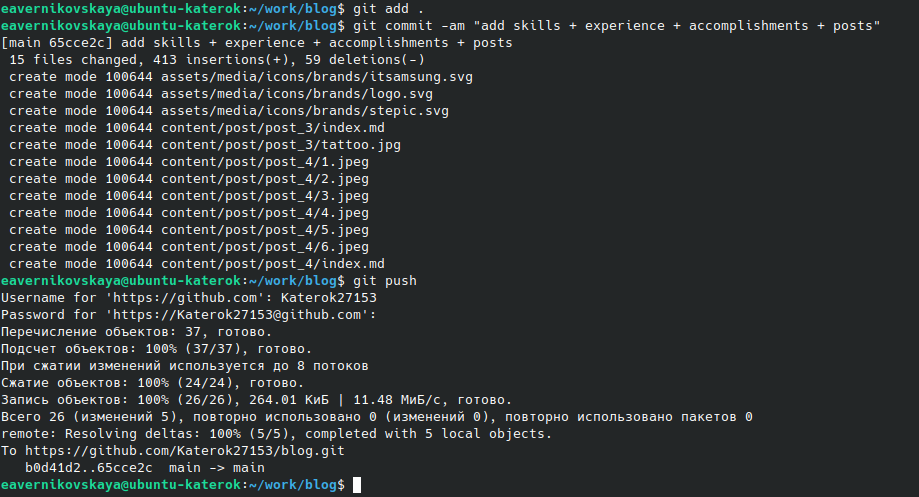

Сохранение и отправка изменений на git

## Сборка сайта

Далее переходим в каталог ~/work/blog/public и также сохраняем изменения и выкладываем их на git (рис. 18), (рис. 19)

[figure not shown]

Сохранение и коммит изменений

## Сборка сайта

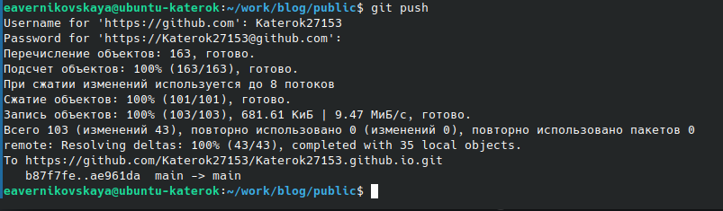

Отправка изменений на git

## Сборка сайта

Далее переходим на наш сайт (не на локальный!) по ссылке katerok27153.github.io и видим что всё получилось (рис. 20), (рис. 21), (рис. 22), (рис. 23]), (рис. 24), (рис. 25)

[figure not shown]

Информация о навыках (skills)

## Сборка сайта

[figure not shown]

Информация об опыте (experience

## Сборка сайта

[figure not shown]

Информация о достижениях (accomplishments)

## Сборка сайта

[figure not shown]

Страница с постами

## Сборка сайта

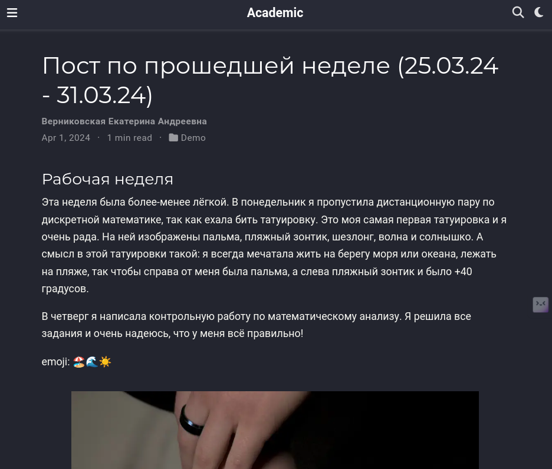

Пост по прошедшей недели

## Сборка сайта

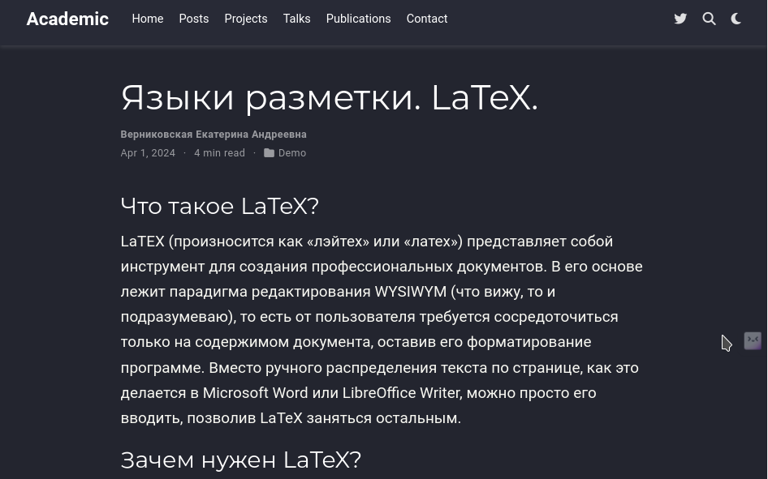

Пост на тему “Языки разметки. LaTeX.”

# Подведение итогов

## Выводы

В ходе выполнения 3-ого этапа индивидуального проекта мы научились размещать на сайте информацю о наших навыках, опыте и достижениях.

## Список литературы

1. Мой сайт [Электронный ресурс] URL: https://katerok27153.github.io/
2. Этапы реализации проекта [Электронный ресурс] URL: https://esystem.rudn.ru/mod/page/view.php?id=1098920
3. Официальная библиотека иконок [Электронный ресурс] URL: https://fontawesome.ru/all-icons/